# Predictors of BMI, by Hannah Mohun

## Data

The Health and Retirement Study is a longitudinal study of health, retirement and aging sponsored by the National Institute on Aging

- Conducted through University of Michigan
- Launched in 1992
- Longitudinal study
- Testing adults over 50 once every 2 years

## Load Data

```r
dsM <- readRDS("./data/derived/dsM.rds")
```

## Variables of interest

- BMI
- Gender
- Age
- Years of education
- Vigorous activity
- Cognition
- Psychiatric issues

## Data Exploration

## Histogram BMI

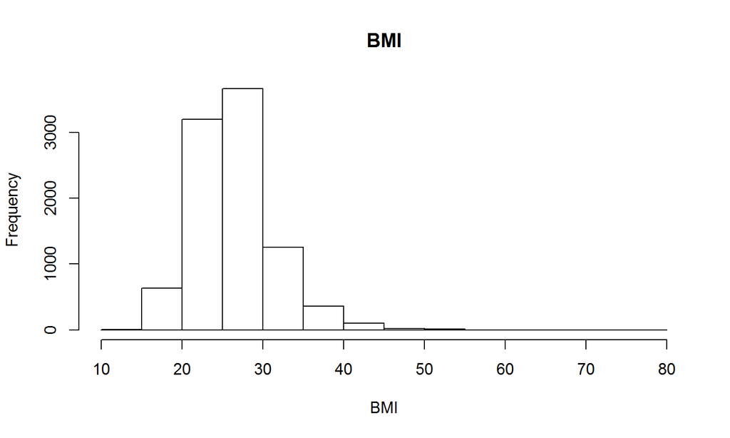

## Histogram Age

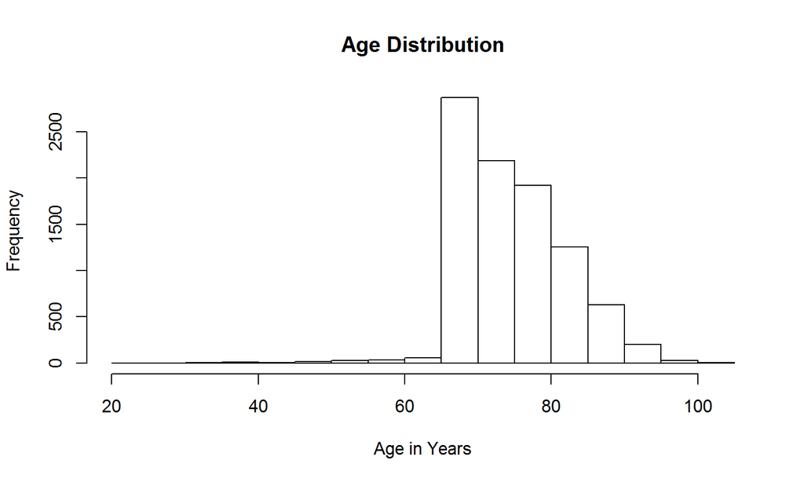

## Histogram Cognition

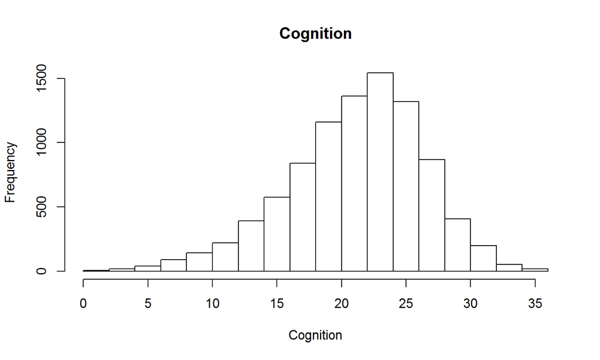

## Histogram Years of Education

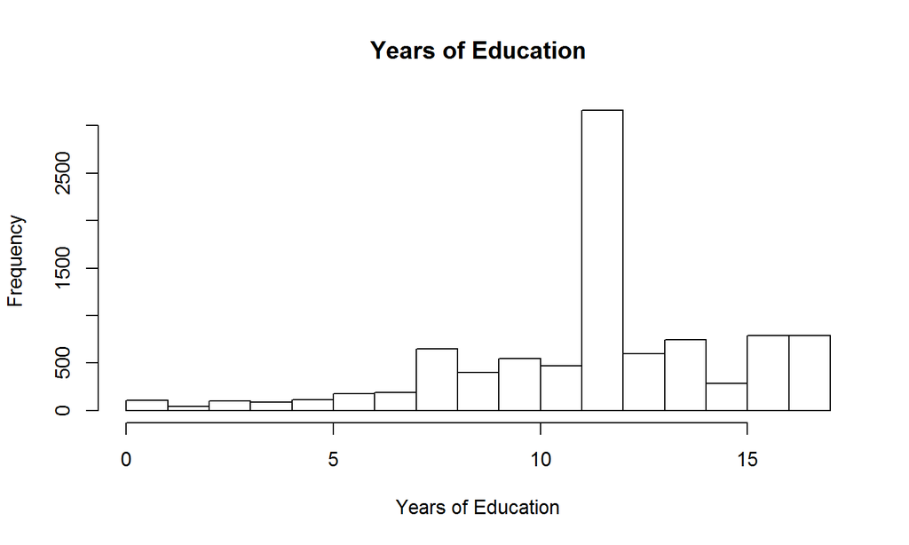

## Scatterplot

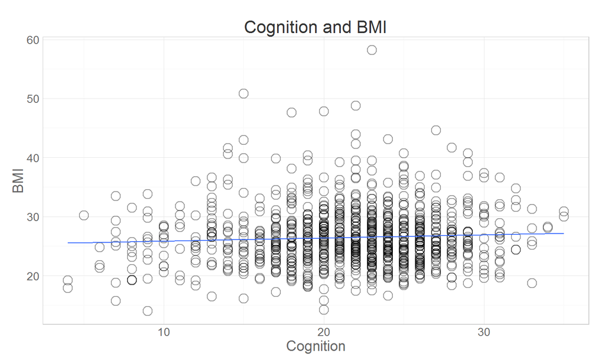

The general trend of this scatterplot suggests that BMI increases as cognition increases

## Scatterplot

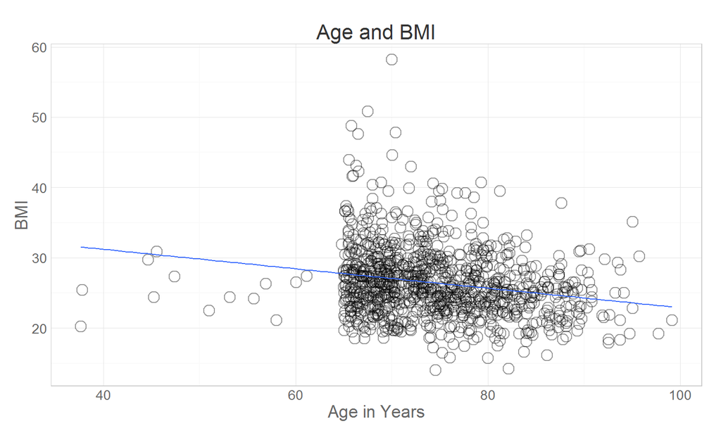

The general trend of this scatterplot suggests that as individuals get older, BMI decreases

## Scatterplot

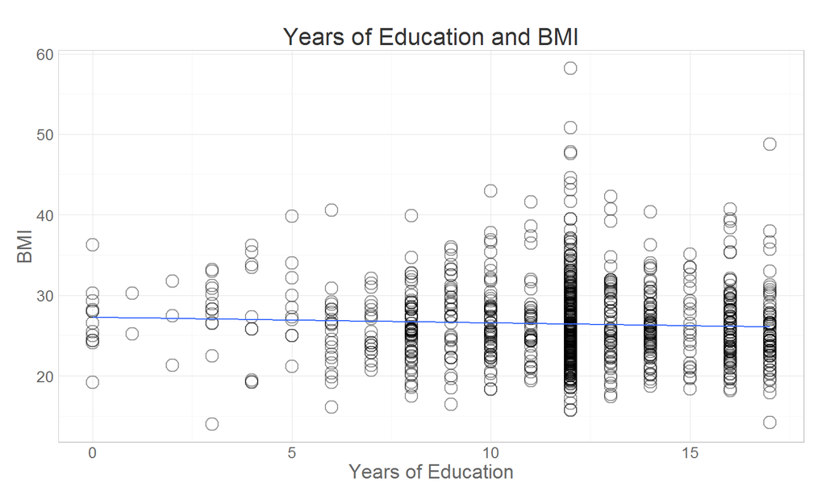

The general trend of this scatterplot suggests that as years of education increases, BMI decreases

## Data

To view a snapshot of the data

```r
head(dsM)
```

```
  psych ragender vigact cogtot     agey  bmi raedyrs wave
1     1        2      0     14 65.41666 17.4       8    5
2     0        1      0     20 71.50000 29.1      17    5
3     0        2      1     27 66.75000 26.6      17    5
4     0        2      0     28 67.75000 27.6       8    5
5     1        2      0     16 65.66666 23.4      12    5
6     1        2      1     18 65.25000 31.5       8    5
```

## Creating a Model to Predict BMI

## Subset Selection

- Regsubsets function performs best subset selection (using RSS)
- Best subset selection fits a separate least squares regression for each possible combination of the p predictors

## Best Subset Selection

```
Subset selection object
Call: regsubsets.formula(bmi ~ agey + cogtot + raedyrs + vigact + ragender +
    psych, data = dsM, nvmax = 10)
6 Variables  (and intercept)
         Forced in Forced out
agey         FALSE      FALSE
cogtot       FALSE      FALSE
raedyrs      FALSE      FALSE
vigact       FALSE      FALSE
ragender     FALSE      FALSE
psych        FALSE      FALSE
1 subsets of each size up to 6
Selection Algorithm: exhaustive
         agey cogtot raedyrs vigact ragender psych
1  ( 1 ) "*"  " "    " "     " "    " "      " "
2  ( 1 ) "*"  " "    "*"     " "    " "      " "
3  ( 1 ) "*"  " "    "*"     "*"    " "      " "
4  ( 1 ) "*"  " "    "*"     "*"    "*"      " "
5  ( 1 ) "*"  " "    "*"     "*"    "*"      "*"
6  ( 1 ) "*"  "*"    "*"     "*"    "*"      "*"
```

## Best Subset Selection Forward Stepwise

- Forward stepwise begins with a model containing no predictors, and then adds predictors to the model one-at-a-time, until all predictors are in the model.

## Forward

```
Subset selection object
Call: regsubsets.formula(bmi ~ raedyrs + vigact + psych + agey + cogtot +
    ragender, data = dsM, nvmax = 10, method = "forward")
6 Variables  (and intercept)
         Forced in Forced out
raedyrs      FALSE      FALSE
vigact       FALSE      FALSE
psych        FALSE      FALSE
agey         FALSE      FALSE
cogtot       FALSE      FALSE
ragender     FALSE      FALSE
1 subsets of each size up to 6
Selection Algorithm: forward
         raedyrs vigact psych agey cogtot ragender
1  ( 1 ) " "     " "    " "   "*"  " "    " "
2  ( 1 ) "*"     " "    " "   "*"  " "    " "
3  ( 1 ) "*"     "*"    " "   "*"  " "    " "
4  ( 1 ) "*"     "*"    " "   "*"  " "    "*"
5  ( 1 ) "*"     "*"    "*"   "*"  " "    "*"
6  ( 1 ) "*"     "*"    "*"   "*"  "*"    "*"
```

## Best Subset Selection Backward Stepwise

- Backward stepwise begins with the full least squares model containing all p predictors, and then removes the least useful predictor one-at-a-time.

## Backward

```
Subset selection object
Call: regsubsets.formula(bmi ~ raedyrs + vigact + psych + agey + cogtot +
    ragender, data = dsM, nvmax = 10, method = "backward")
6 Variables  (and intercept)
         Forced in Forced out
raedyrs      FALSE      FALSE
vigact       FALSE      FALSE
psych        FALSE      FALSE
agey         FALSE      FALSE
cogtot       FALSE      FALSE
ragender     FALSE      FALSE
1 subsets of each size up to 6
Selection Algorithm: backward
         raedyrs vigact psych agey cogtot ragender
1  ( 1 ) " "     " "    " "   "*"  " "    " "
2  ( 1 ) "*"     " "    " "   "*"  " "    " "
3  ( 1 ) "*"     "*"    " "   "*"  " "    " "
4  ( 1 ) "*"     "*"    " "   "*"  " "    "*"
5  ( 1 ) "*"     "*"    "*"   "*"  " "    "*"
6  ( 1 ) "*"     "*"    "*"   "*"  "*"    "*"
```

## Adjusted r-squared, Cp, and BIC

- Adjusted r-squared says that a model with 5 factors is optimal

```
[1] 5
```

- Cp says that a model with 4 factors is optimal

```
[1] 4
```

- BIC says that a model with 4 factors is optimal

```
[1] 4
```

## Plot

- Plot Adjusted r-squared with a point on the which.max() value calculated above

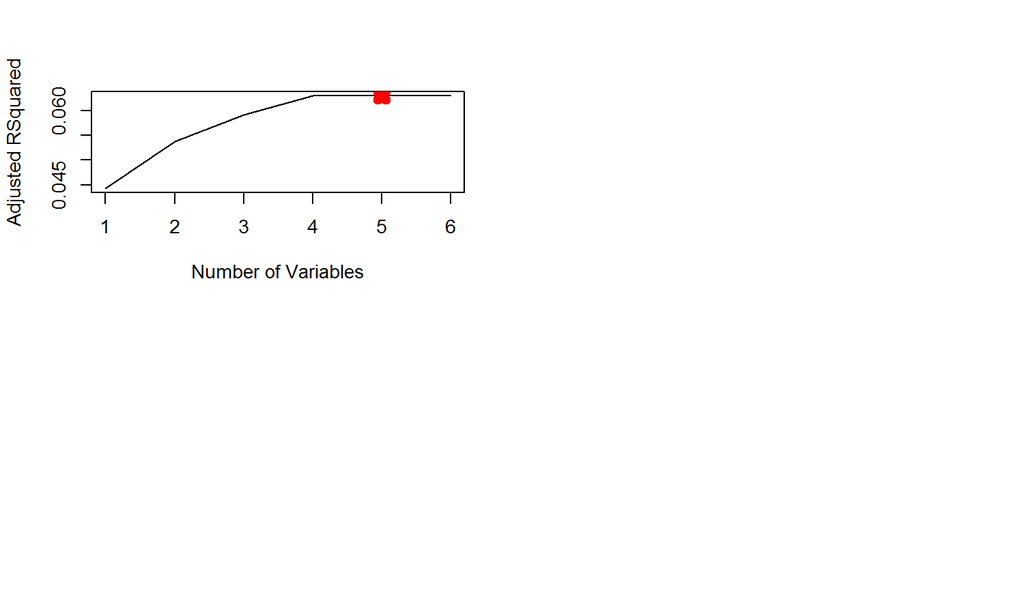

## Plot

- Plot Cp with a point on the which.min() value calculated above

[figure not shown]

## Plot

- Plot BIC with a point on the which.min() value calculated above

[figure not shown]

## Linear Models

- Linear model with all 6 factors
- The linear model with all 6 factors shows that all variables are significant predictors of BMI except for psychiatric issues and cognition.

```
Call:
lm(formula = bmi ~ raedyrs + vigact + agey + ragender + cogtot +
    psych + raedyrs, data = dsM)

Residuals:
    Min      1Q  Median      3Q     Max
-14.242  -3.125  -0.432   2.485  50.416

Coefficients:
             Estimate Std. Error t value Pr(>|t|)
(Intercept) 40.596157   0.663957  61.143  < 2e-16 ***
raedyrs     -0.138125   0.016631  -8.305  < 2e-16 ***
vigact      -0.816840   0.104130  -7.844 4.83e-15 ***
agey        -0.151980   0.007219 -21.053  < 2e-16 ***
ragender    -0.648638   0.102246  -6.344 2.35e-10 ***
cogtot       0.006229   0.011285   0.552    0.581
psych        0.197129   0.155034   1.272    0.204
---
Signif. codes:  0 '***' 0.001 '**' 0.01 '*' 0.05 '.' 0.1 ' ' 1

Residual standard error: 4.754 on 9242 degrees of freedom
Multiple R-squared:  0.06358,   Adjusted R-squared:  0.06297
F-statistic: 104.6 on 6 and 9242 DF,  p-value: < 2.2e-16
```

## Model with 5 factors

- Relationship of BMI with vigorous activity, age, gender, years of education, and psychiatric issues
- These variables chosen by looking at best subset selection
- This is the optimal model size suggested by adjusted r-squared which.max() function

## Model with 5 factors

- The linear model with 5 variables shows that all variables are significant predictors of BMI except for psychiatric issues

```
Call:
lm(formula = bmi ~ raedyrs + vigact + agey + ragender + psych,
    data = dsM)

Residuals:
    Min      1Q  Median      3Q     Max
-14.269  -3.130  -0.431   2.484  50.437

Coefficients:
             Estimate Std. Error t value Pr(>|t|)
(Intercept) 40.768813   0.585641  69.614  < 2e-16 ***
raedyrs     -0.134170   0.015008  -8.940  < 2e-16 ***
vigact      -0.811285   0.103639  -7.828 5.50e-15 ***
agey        -0.153272   0.006828 -22.447  < 2e-16 ***
ragender    -0.642432   0.101622  -6.322 2.71e-10 ***
psych        0.192351   0.154787   1.243    0.214
---
Signif. codes:  0 '***' 0.001 '**' 0.01 '*' 0.05 '.' 0.1 ' ' 1

Residual standard error: 4.754 on 9243 degrees of freedom
Multiple R-squared:  0.06355,   Adjusted R-squared:  0.06304
F-statistic: 125.4 on 5 and 9243 DF,  p-value: < 2.2e-16
```

## Model with 4 factors

- Relationship of BMI with vigorous activity, age, gender, and years of education
- Variables were chosen by looking at best subset selection
- This is the optimal model size suggested by Cp and BIC which.min() function

## Model with 4 factors

- The linear model with 4 variables shows that all variables are significant predictors of BMI

```
Call:
lm(formula = bmi ~ raedyrs + vigact + agey + ragender, data = dsM)

Residuals:
    Min      1Q  Median      3Q     Max
-14.317  -3.136  -0.443   2.482  50.412

Coefficients:
             Estimate Std. Error t value Pr(>|t|)
(Intercept) 40.833693   0.583327  70.001  < 2e-16 ***
raedyrs     -0.136005   0.014936  -9.106  < 2e-16 ***
vigact      -0.822788   0.103227  -7.971 1.77e-15 ***
agey        -0.153723   0.006819 -22.545  < 2e-16 ***
ragender    -0.631042   0.101211  -6.235 4.72e-10 ***
---
Signif. codes:  0 '***' 0.001 '**' 0.01 '*' 0.05 '.' 0.1 ' ' 1

Residual standard error: 4.754 on 9244 degrees of freedom
Multiple R-squared:  0.06339,   Adjusted R-squared:  0.06299
F-statistic: 156.4 on 4 and 9244 DF,  p-value: < 2.2e-16
```

## Linear model with cognition

- Wanted to explore whether cognition would be a significant predictor on its own in a model since it was not significant in the model with 6 factors

```
Call:
lm(formula = bmi ~ cogtot, data = dsM)

Residuals:
    Min      1Q  Median      3Q     Max
-13.837  -3.320  -0.614   2.609  48.995

Coefficients:
             Estimate Std. Error t value Pr(>|t|)
(Intercept) 25.933931   0.216374 119.857   <2e-16 ***
cogtot       0.022856   0.009723   2.351   0.0188 *
---
Signif. codes:  0 '***' 0.001 '**' 0.01 '*' 0.05 '.' 0.1 ' ' 1

Residual standard error: 4.91 on 9247 degrees of freedom
Multiple R-squared:  0.0005972, Adjusted R-squared:  0.0004891
F-statistic: 5.525 on 1 and 9247 DF,  p-value: 0.01876
```

- WOW! How deceiving.

## Linear model with psychiatric issues

```
Call:
lm(formula = bmi ~ psych, data = dsM)

Residuals:
    Min      1Q  Median      3Q     Max
-13.774  -3.331  -0.574   2.626  49.126

Coefficients:
            Estimate Std. Error t value Pr(>|t|)
(Intercept)  26.3735     0.0544 484.850  < 2e-16 ***
psych         0.4574     0.1574   2.907  0.00366 **
---
Signif. codes:  0 '***' 0.001 '**' 0.01 '*' 0.05 '.' 0.1 ' ' 1

Residual standard error: 4.909 on 9247 degrees of freedom
Multiple R-squared:  0.0009128, Adjusted R-squared:  0.0008047
F-statistic: 8.448 on 1 and 9247 DF,  p-value: 0.003663
```

- WOW! How deceiving.

## Linear model with cognition and psychiatric issues

```
Call:
lm(formula = bmi ~ cogtot + psych, data = dsM)

Residuals:
    Min      1Q  Median      3Q     Max
-13.779  -3.304  -0.579   2.600  49.045

Coefficients:
             Estimate Std. Error t value Pr(>|t|)
(Intercept) 25.820511   0.219317 117.731  < 2e-16 ***
cogtot       0.025385   0.009753   2.603  0.00926 **
psych        0.491626   0.157871   3.114  0.00185 **
---
Signif. codes:  0 '***' 0.001 '**' 0.01 '*' 0.05 '.' 0.1 ' ' 1

Residual standard error: 4.907 on 9246 degrees of freedom
Multiple R-squared:  0.001644,  Adjusted R-squared:  0.001428
F-statistic: 7.614 on 2 and 9246 DF,  p-value: 0.0004965
```

- WOW! How deceiving.

## Final linear model

- The final model I chose to predict BMI is the model with 4 factors (age, years of education, gender, and vigorous activity).
- Both BIC and Cp had the lowest values with this model size, and best subset selection (all 3 methods) suggested that these 4 factors should be the factors included in this size model.
- All factors within this model are statistically significant predictors of BMI, whereas in the 5 factor model psychiatric issues wasn't significant

## Final linear model

```
Call:
lm(formula = bmi ~ raedyrs + vigact + agey + ragender, data = dsM)

Residuals:
    Min      1Q  Median      3Q     Max
-14.317  -3.136  -0.443   2.482  50.412

Coefficients:
             Estimate Std. Error t value Pr(>|t|)
(Intercept) 40.833693   0.583327  70.001  < 2e-16 ***
raedyrs     -0.136005   0.014936  -9.106  < 2e-16 ***
vigact      -0.822788   0.103227  -7.971 1.77e-15 ***
agey        -0.153723   0.006819 -22.545  < 2e-16 ***
ragender    -0.631042   0.101211  -6.235 4.72e-10 ***
---
Signif. codes:  0 '***' 0.001 '**' 0.01 '*' 0.05 '.' 0.1 ' ' 1

Residual standard error: 4.754 on 9244 degrees of freedom
Multiple R-squared:  0.06339,   Adjusted R-squared:  0.06299
F-statistic: 156.4 on 4 and 9244 DF,  p-value: < 2.2e-16
```

## Coefficients

The coefficients tell us the as BMI increases by 1 point:

- vigorous activity decreases by (.82, SD=.103)
- age decreases by (.15, SD=.007)
- the effect of being male increases by (.63, SD=.101)
- and years of education decreases by (.14, SD=.015).

## Conclusion

## To summarize

- From the 6 initial predictors in my dataset, I found that the model with age, years of education, vigorous activity and gender best predicts BMI
- The coefficients tell us that as BMI increases:
- age decreases
- years of education decreases
- effect of being male increases
- Also discovered how misleading linear models can be when I looked into cognition and psychiatric issues on their own

[figure not shown]